# What Sneaker is That?

### Remove images that can't be opened

```python
path = Path('data/what_sneaker_2')
```

```python
# Need to list every class (folder name from above. This will be used by the for loop below)
classes = ['air_jordan_1', 'air_jordan_2', 'air_jordan_3', 'air_jordan_4', 'air_jordan_5',
           'air_jordan_6', 'air_jordan_7', 'air_jordan_8', 'air_jordan_9', 'air_jordan_10',
           'air_jordan_11', 'air_jordan_12', 'air_jordan_13', 'air_jordan_14', 'air_jordan_15',
           'air_max_1', 'air_max_90', 'air_max_95', 'air_max_97', 'air_max_270', 'epic_react',
           'foamposite', 'pegasus_35', 'vapormax']
```

Then we can remove any images that can't be opened:

```python
for c in classes:
    print(c)
    verify_images(path/c, delete=True, max_size=500)
```

```
air_jordan_1
```

100.00% [193/193 00:02<00:00]

```
cannot identify image file <_io.BufferedReader name='data/what_sneaker_2/air_jordan_1/00000190.jpg'>
cannot identify image file <_io.BufferedReader name='data/what_sneaker_2/air_jordan_1/00000078.png'>
cannot identify image file <_io.BufferedReader name='data/what_sneaker_2/air_jordan_1/00000101.jpg'>
cannot identify image file <_io.BufferedReader name='data/what_sneaker_2/air_jordan_1/00000072.jpg'>
cannot identify image file <_io.BufferedReader name='data/what_sneaker_2/air_jordan_1/00000094.jpg'>
cannot identify image file <_io.BufferedReader name='data/what_sneaker_2/air_jordan_1/00000056.jpg'>
cannot identify image file <_io.BufferedReader name='data/what_sneaker_2/air_jordan_1/00000163.jpg'>
cannot identify image file <_io.BufferedReader name='data/what_sneaker_2/air_jordan_1/00000086.jpg'>
cannot identify image file <_io.BufferedReader name='data/what_sneaker_2/air_jordan_1/00000102.jpg'>
cannot identify image file <_io.BufferedReader name='data/what_sneaker_2/air_jordan_1/00000104.jpg'>
cannot identify image file <_io.BufferedReader name='data/what_sneaker_2/air_jordan_1/00000109.jpg'>
cannot identify image file <_io.BufferedReader name='data/what_sneaker_2/air_jordan_1/00000064.jpg'>
cannot identify image file <_io.BufferedReader name='data/what_sneaker_2/air_jordan_1/00000144.png'>
cannot identify image file <_io.BufferedReader name='data/what_sneaker_2/air_jordan_1/00000026.jpg'>
cannot identify image file <_io.BufferedReader name='data/what_sneaker_2/air_jordan_1/00000151.jpg'>
cannot identify image file <_io.BufferedReader name='data/what_sneaker_2/air_jordan_1/00000065.jpg'>
cannot identify image file <_io.BufferedReader name='data/what_sneaker_2/air_jordan_1/00000126.jpg'>
cannot identify image file <_io.BufferedReader name='data/what_sneaker_2/air_jordan_1/00000107.jpg'>
cannot identify image file <_io.BufferedReader name='data/what_sneaker_2/air_jordan_1/00000049.jpg'>
cannot identify image file <_io.BufferedReader name='data/what_sneaker_2/air_jordan_1/00000090.jpg'>
cannot identify image file <_io.BufferedReader name='data/what_sneaker_2/air_jordan_1/00000016.jpg'>
cannot identify image file <_io.BufferedReader name='data/what_sneaker_2/air_jordan_1/00000087.jpg'>
cannot identify image file <_io.BufferedReader name='data/what_sneaker_2/air_jordan_1/00000039.jpg'>
cannot identify image file <_io.BufferedReader name='data/what_sneaker_2/air_jordan_1/00000112.jpg'>
air_jordan_2
```

100.00% [170/170 00:00<00:00]

```
cannot identify image file <_io.BufferedReader name='data/what_sneaker_2/air_jordan_2/00000126.png'>
cannot identify image file <_io.BufferedReader name='data/what_sneaker_2/air_jordan_2/00000060.png'>
cannot identify image file <_io.BufferedReader name='data/what_sneaker_2/air_jordan_2/00000069.jpg'>
cannot identify image file <_io.BufferedReader name='data/what_sneaker_2/air_jordan_2/00000082.jpg'>
cannot identify image file <_io.BufferedReader name='data/what_sneaker_2/air_jordan_2/00000067.png'>
cannot identify image file <_io.BufferedReader name='data/what_sneaker_2/air_jordan_2/00000016.png'>
cannot identify image file <_io.BufferedReader name='data/what_sneaker_2/air_jordan_2/00000118.jpg'>
Image data/what_sneaker_2/air_jordan_2/00000104.png has 4 instead of 3 channels
cannot identify image file <_io.BufferedReader name='data/what_sneaker_2/air_jordan_2/00000008.png'>
```

```
Image data/what_sneaker_2/air_jordan_2/00000089.png has 1 instead of 3 channels
cannot identify image file <_io.BufferedReader name='data/what_sneaker_2/air_jordan_2/00000043.jpg'>
cannot identify image file <_io.BufferedReader name='data/what_sneaker_2/air_jordan_2/00000012.jpeg'>
cannot identify image file <_io.BufferedReader name='data/what_sneaker_2/air_jordan_2/00000087.png'>
cannot identify image file <_io.BufferedReader name='data/what_sneaker_2/air_jordan_2/00000114.jpg'>
cannot identify image file <_io.BufferedReader name='data/what_sneaker_2/air_jordan_2/00000135.jpg'>
cannot identify image file <_io.BufferedReader name='data/what_sneaker_2/air_jordan_2/00000071.jpg'>
cannot identify image file <_io.BufferedReader name='data/what_sneaker_2/air_jordan_2/00000007.jpg'>
cannot identify image file <_io.BufferedReader name='data/what_sneaker_2/air_jordan_2/00000139.png'>
cannot identify image file <_io.BufferedReader name='data/what_sneaker_2/air_jordan_2/00000106.jpg'>
cannot identify image file <_io.BufferedReader name='data/what_sneaker_2/air_jordan_2/00000033.jpg'>
cannot identify image file <_io.BufferedReader name='data/what_sneaker_2/air_jordan_2/00000055.png'>
cannot identify image file <_io.BufferedReader name='data/what_sneaker_2/air_jordan_2/00000025.jpg'>
cannot identify image file <_io.BufferedReader name='data/what_sneaker_2/air_jordan_2/00000136.jpg'>
cannot identify image file <_io.BufferedReader name='data/what_sneaker_2/air_jordan_2/00000105.png'>
cannot identify image file <_io.BufferedReader name='data/what_sneaker_2/air_jordan_2/00000143.jpg'>
cannot identify image file <_io.BufferedReader name='data/what_sneaker_2/air_jordan_2/00000131.png'>
cannot identify image file <_io.BufferedReader name='data/what_sneaker_2/air_jordan_2/00000161.jpg'>
cannot identify image file <_io.BufferedReader name='data/what_sneaker_2/air_jordan_2/00000048.jpg'>
cannot identify image file <_io.BufferedReader name='data/what_sneaker_2/air_jordan_2/00000038.jpg'>
cannot identify image file <_io.BufferedReader name='data/what_sneaker_2/air_jordan_2/00000132.jpg'>
cannot identify image file <_io.BufferedReader name='data/what_sneaker_2/air_jordan_2/00000152.jpg'>
cannot identify image file <_io.BufferedReader name='data/what_sneaker_2/air_jordan_2/00000097.jpg'>
cannot identify image file <_io.BufferedReader name='data/what_sneaker_2/air_jordan_2/00000149.png'>
```

```
air_jordan_3
```

100.00% [198/198 00:01<00:00]

```
cannot identify image file <_io.BufferedReader name='data/what_sneaker_2/air_jordan_3/00000172.jpg'>
cannot identify image file <_io.BufferedReader name='data/what_sneaker_2/air_jordan_3/00000196.png'>
cannot identify image file <_io.BufferedReader name='data/what_sneaker_2/air_jordan_3/00000158.jpg'>
cannot identify image file <_io.BufferedReader name='data/what_sneaker_2/air_jordan_3/00000033.png'>
cannot identify image file <_io.BufferedReader name='data/what_sneaker_2/air_jordan_3/00000064.png'>
cannot identify image file <_io.BufferedReader name='data/what_sneaker_2/air_jordan_3/00000181.png'>
cannot identify image file <_io.BufferedReader name='data/what_sneaker_2/air_jordan_3/00000126.jpg'>
cannot identify image file <_io.BufferedReader name='data/what_sneaker_2/air_jordan_3/00000197.jpg'>
cannot identify image file <_io.BufferedReader name='data/what_sneaker_2/air_jordan_3/00000144.jpg'>
cannot identify image file <_io.BufferedReader name='data/what_sneaker_2/air_jordan_3/00000095.jpg'>
cannot identify image file <_io.BufferedReader name='data/what_sneaker_2/air_jordan_3/00000041.jpg'>
air_jordan_4
```

100.00% [195/195 00:01<00:00]

```
cannot identify image file <_io.BufferedReader name='data/what_sneaker_2/air_jordan_4/00000140.png'>
cannot identify image file <_io.BufferedReader name='data/what_sneaker_2/air_jordan_4/00000189.jpg'>
cannot identify image file <_io.BufferedReader name='data/what_sneaker_2/air_jordan_4/00000028.jpg'>
cannot identify image file <_io.BufferedReader name='data/what_sneaker_2/air_jordan_4/00000131.jpg'>
cannot identify image file <_io.BufferedReader name='data/what_sneaker_2/air_jordan_4/00000049.png'>
cannot identify image file <_io.BufferedReader name='data/what_sneaker_2/air_jordan_4/00000127.png'>
cannot identify image file <_io.BufferedReader name='data/what_sneaker_2/air_jordan_4/00000188.jpg'>
cannot identify image file <_io.BufferedReader name='data/what_sneaker_2/air_jordan_4/00000179.jpg'>
cannot identify image file <_io.BufferedReader name='data/what_sneaker_2/air_jordan_4/00000152.jpg'>
cannot identify image file <_io.BufferedReader name='data/what_sneaker_2/air_jordan_4/00000061.png'>
air_jordan_5
```

100.00% [193/193 00:01<00:00]

```
cannot identify image file <_io.BufferedReader name='data/what_sneaker_2/air_jordan_5/00000130.jpg'>
cannot identify image file <_io.BufferedReader name='data/what_sneaker_2/air_jordan_5/00000173.jpg'>
cannot identify image file <_io.BufferedReader name='data/what_sneaker_2/air_jordan_5/00000103.jpg'>
cannot identify image file <_io.BufferedReader name='data/what_sneaker_2/air_jordan_5/00000193.jpg'>
cannot identify image file <_io.BufferedReader name='data/what_sneaker_2/air_jordan_5/00000195.jpg'>
cannot identify image file <_io.BufferedReader name='data/what_sneaker_2/air_jordan_5/00000017.jpg'>
cannot identify image file <_io.BufferedReader name='data/what_sneaker_2/air_jordan_5/00000071.jpg'>
cannot identify image file <_io.BufferedReader name='data/what_sneaker_2/air_jordan_5/00000185.jpg'>
cannot identify image file <_io.BufferedReader name='data/what_sneaker_2/air_jordan_5/00000102.jpg'>
cannot identify image file <_io.BufferedReader name='data/what_sneaker_2/air_jordan_5/00000042.jpg'>
Image data/what_sneaker_2/air_jordan_5/00000160.gif has 1 instead of 3 channels
cannot identify image file <_io.BufferedReader name='data/what_sneaker_2/air_jordan_5/00000033.jpg'>
cannot identify image file <_io.BufferedReader name='data/what_sneaker_2/air_jordan_5/00000121.jpg'>
cannot identify image file <_io.BufferedReader name='data/what_sneaker_2/air_jordan_5/00000025.jpg'>
cannot identify image file <_io.BufferedReader name='data/what_sneaker_2/air_jordan_5/00000119.jpg'>
cannot identify image file <_io.BufferedReader name='data/what_sneaker_2/air_jordan_5/00000093.jpg'>
cannot identify image file <_io.BufferedReader name='data/what_sneaker_2/air_jordan_5/00000198.jpg'>
cannot identify image file <_io.BufferedReader name='data/what_sneaker_2/air_jordan_5/00000001.jpg'>
cannot identify image file <_io.BufferedReader name='data/what_sneaker_2/air_jordan_5/00000090.jpg'>
cannot identify image file <_io.BufferedReader name='data/what_sneaker_2/air_jordan_5/00000148.jpg'>
air_jordan_6
```

100.00% [192/192 00:01<00:00]

```
cannot identify image file <_io.BufferedReader name='data/what_sneaker_2/air_jordan_6/00000060.jpg'>
cannot identify image file <_io.BufferedReader name='data/what_sneaker_2/air_jordan_6/00000145.png'>
cannot identify image file <_io.BufferedReader name='data/what_sneaker_2/air_jordan_6/00000084.png'>
cannot identify image file <_io.BufferedReader name='data/what_sneaker_2/air_jordan_6/00000154.jpg'>
```

```
cannot identify image file <_io.BufferedReader name='data/what_sneaker_2/air_jordan_6/00000142.png'>
cannot identify image file <_io.BufferedReader name='data/what_sneaker_2/air_jordan_6/00000064.jpg'>
cannot identify image file <_io.BufferedReader name='data/what_sneaker_2/air_jordan_6/00000143.jpg'>
cannot identify image file <_io.BufferedReader name='data/what_sneaker_2/air_jordan_6/00000073.jpg'>
cannot identify image file <_io.BufferedReader name='data/what_sneaker_2/air_jordan_6/00000170.jpg'>
air_jordan_7
```

100.00% [197/197 00:01<00:00]

```
cannot identify image file <_io.BufferedReader name='data/what_sneaker_2/air_jordan_7/00000118.jpg'>
cannot identify image file <_io.BufferedReader name='data/what_sneaker_2/air_jordan_7/00000146.jpg'>
```

```
cannot identify image file <_io.BufferedReader name='data/what_sneaker_2/air_jordan_7/00000176.jpg'>
```

```
cannot identify image file <_io.BufferedReader name='data/what_sneaker_2/air_jordan_7/00000104.jpg'>
cannot identify image file <_io.BufferedReader name='data/what_sneaker_2/air_jordan_7/00000100.png'>
cannot identify image file <_io.BufferedReader name='data/what_sneaker_2/air_jordan_7/00000046.jpg'>
cannot identify image file <_io.BufferedReader name='data/what_sneaker_2/air_jordan_7/00000081.jpg'>
cannot identify image file <_io.BufferedReader name='data/what_sneaker_2/air_jordan_7/00000064.jpg'>
cannot identify image file <_io.BufferedReader name='data/what_sneaker_2/air_jordan_7/00000121.jpg'>
cannot identify image file <_io.BufferedReader name='data/what_sneaker_2/air_jordan_7/00000188.jpg'>
```

```
cannot identify image file <_io.BufferedReader name='data/what_sneaker_2/air_jordan_7/00000131.png'>
cannot identify image file <_io.BufferedReader name='data/what_sneaker_2/air_jordan_7/00000151.jpg'>
cannot identify image file <_io.BufferedReader name='data/what_sneaker_2/air_jordan_7/00000065.jpg'>
cannot identify image file <_io.BufferedReader name='data/what_sneaker_2/air_jordan_7/00000088.jpg'>
cannot identify image file <_io.BufferedReader name='data/what_sneaker_2/air_jordan_7/00000140.jpg'>
cannot identify image file <_io.BufferedReader name='data/what_sneaker_2/air_jordan_7/00000055.jpg'>
cannot identify image file <_io.BufferedReader name='data/what_sneaker_2/air_jordan_7/00000097.jpg'>
cannot identify image file <_io.BufferedReader name='data/what_sneaker_2/air_jordan_7/00000170.png'>
cannot identify image file <_io.BufferedReader name='data/what_sneaker_2/air_jordan_7/00000095.jpg'>
cannot identify image file <_io.BufferedReader name='data/what_sneaker_2/air_jordan_7/00000030.jpg'>
air_jordan_8
```

100.00% [197/197 00:01<00:00]

```
cannot identify image file <_io.BufferedReader name='data/what_sneaker_2/air_jordan_8/00000023.jpg'>
cannot identify image file <_io.BufferedReader name='data/what_sneaker_2/air_jordan_8/00000060.png'>
cannot identify image file <_io.BufferedReader name='data/what_sneaker_2/air_jordan_8/00000078.png'>
cannot identify image file <_io.BufferedReader name='data/what_sneaker_2/air_jordan_8/00000122.jpg'>
cannot identify image file <_io.BufferedReader name='data/what_sneaker_2/air_jordan_8/00000083.jpg'>
cannot identify image file <_io.BufferedReader name='data/what_sneaker_2/air_jordan_8/00000169.jpg'>
cannot identify image file <_io.BufferedReader name='data/what_sneaker_2/air_jordan_8/00000028.jpg'>
cannot identify image file <_io.BufferedReader name='data/what_sneaker_2/air_jordan_8/00000165.jpg'>
cannot identify image file <_io.BufferedReader name='data/what_sneaker_2/air_jordan_8/00000103.jpg'>
cannot identify image file <_io.BufferedReader name='data/what_sneaker_2/air_jordan_8/00000131.jpg'>
cannot identify image file <_io.BufferedReader name='data/what_sneaker_2/air_jordan_8/00000124.jpg'>
cannot identify image file <_io.BufferedReader name='data/what_sneaker_2/air_jordan_8/00000146.jpg'>
cannot identify image file <_io.BufferedReader name='data/what_sneaker_2/air_jordan_8/00000137.png'>
cannot identify image file <_io.BufferedReader name='data/what_sneaker_2/air_jordan_8/00000052.png'>
cannot identify image file <_io.BufferedReader name='data/what_sneaker_2/air_jordan_8/00000135.jpg'>
cannot identify image file <_io.BufferedReader name='data/what_sneaker_2/air_jordan_8/00000134.jpg'>
cannot identify image file <_io.BufferedReader name='data/what_sneaker_2/air_jordan_8/00000113.jpg'>
cannot identify image file <_io.BufferedReader name='data/what_sneaker_2/air_jordan_8/00000001.png'>
cannot identify image file <_io.BufferedReader name='data/what_sneaker_2/air_jordan_8/00000104.jpg'>
cannot identify image file <_io.BufferedReader name='data/what_sneaker_2/air_jordan_8/00000061.jpg'>
cannot identify image file <_io.BufferedReader name='data/what_sneaker_2/air_jordan_8/00000063.png'>
cannot identify image file <_io.BufferedReader name='data/what_sneaker_2/air_jordan_8/00000154.jpg'>
cannot identify image file <_io.BufferedReader name='data/what_sneaker_2/air_jordan_8/00000164.jpg'>
cannot identify image file <_io.BufferedReader name='data/what_sneaker_2/air_jordan_8/00000121.jpg'>
cannot identify image file <_io.BufferedReader name='data/what_sneaker_2/air_jordan_8/00000119.jpg'>
cannot identify image file <_io.BufferedReader name='data/what_sneaker_2/air_jordan_8/00000097.jpg'>
cannot identify image file <_io.BufferedReader name='data/what_sneaker_2/air_jordan_8/00000074.jpg'>
cannot identify image file <_io.BufferedReader name='data/what_sneaker_2/air_jordan_8/00000150.jpg'>
cannot identify image file <_io.BufferedReader name='data/what_sneaker_2/air_jordan_8/00000197.jpg'>
cannot identify image file <_io.BufferedReader name='data/what_sneaker_2/air_jordan_8/00000195.png'>
cannot identify image file <_io.BufferedReader name='data/what_sneaker_2/air_jordan_8/00000016.jpg'>
cannot identify image file <_io.BufferedReader name='data/what_sneaker_2/air_jordan_8/00000148.jpg'>
cannot identify image file <_io.BufferedReader name='data/what_sneaker_2/air_jordan_8/00000040.jpg'>
air_jordan_9
```

100.00% [197/197 00:01<00:00]

```
cannot identify image file <_io.BufferedReader name='data/what_sneaker_2/air_jordan_9/00000130.jpg'>
cannot identify image file <_io.BufferedReader name='data/what_sneaker_2/air_jordan_9/00000010.jpg'>
cannot identify image file <_io.BufferedReader name='data/what_sneaker_2/air_jordan_9/00000118.jpg'>
cannot identify image file <_io.BufferedReader name='data/what_sneaker_2/air_jordan_9/00000198.png'>
cannot identify image file <_io.BufferedReader name='data/what_sneaker_2/air_jordan_9/00000103.jpg'>
cannot identify image file <_io.BufferedReader name='data/what_sneaker_2/air_jordan_9/00000049.png'>
Image data/what_sneaker_2/air_jordan_9/00000029.png has 1 instead of 3 channels
cannot identify image file <_io.BufferedReader name='data/what_sneaker_2/air_jordan_9/00000105.jpg'>
cannot identify image file <_io.BufferedReader name='data/what_sneaker_2/air_jordan_9/00000015.jpg'>
cannot identify image file <_io.BufferedReader name='data/what_sneaker_2/air_jordan_9/00000026.png'>
cannot identify image file <_io.BufferedReader name='data/what_sneaker_2/air_jordan_9/00000178.jpg'>
cannot identify image file <_io.BufferedReader name='data/what_sneaker_2/air_jordan_9/00000085.jpg'>
cannot identify image file <_io.BufferedReader name='data/what_sneaker_2/air_jordan_9/00000134.jpg'>
cannot identify image file <_io.BufferedReader name='data/what_sneaker_2/air_jordan_9/00000090.png'>
```

```
cannot identify image file <_io.BufferedReader name='data/what_sneaker_2/air_jordan_9/00000168.jpg'>
cannot identify image file <_io.BufferedReader name='data/what_sneaker_2/air_jordan_9/00000117.png'>
```

```
cannot identify image file <_io.BufferedReader name='data/what_sneaker_2/air_jordan_9/00000187.jpg'>
Image data/what_sneaker_2/air_jordan_9/00000002.png has 1 instead of 3 channels
cannot identify image file <_io.BufferedReader name='data/what_sneaker_2/air_jordan_9/00000107.jpg'>
cannot identify image file <_io.BufferedReader name='data/what_sneaker_2/air_jordan_9/00000132.jpg'>
Image data/what_sneaker_2/air_jordan_9/00000194.jpg has 1 instead of 3 channels
cannot identify image file <_io.BufferedReader name='data/what_sneaker_2/air_jordan_9/00000182.jpg'>
cannot identify image file <_io.BufferedReader name='data/what_sneaker_2/air_jordan_9/00000041.jpg'>
cannot identify image file <_io.BufferedReader name='data/what_sneaker_2/air_jordan_9/00000066.jpg'>
```

```
air_jordan_10
```

100.00% [195/195 00:01<00:00]

```
cannot identify image file <_io.BufferedReader name='data/what_sneaker_2/air_jordan_10/00000126.png'>
cannot identify image file <_io.BufferedReader name='data/what_sneaker_2/air_jordan_10/00000129.jpg'>
cannot identify image file <_io.BufferedReader name='data/what_sneaker_2/air_jordan_10/00000176.png'>
cannot identify image file <_io.BufferedReader name='data/what_sneaker_2/air_jordan_10/00000118.jpg'>
cannot identify image file <_io.BufferedReader name='data/what_sneaker_2/air_jordan_10/00000044.jpg'>
cannot identify image file <_io.BufferedReader name='data/what_sneaker_2/air_jordan_10/00000051.png'>
cannot identify image file <_io.BufferedReader name='data/what_sneaker_2/air_jordan_10/00000076.png'>
cannot identify image file <_io.BufferedReader name='data/what_sneaker_2/air_jordan_10/00000049.png'>
Image data/what_sneaker_2/air_jordan_10/00000029.png has 4 instead of 3 channels
cannot identify image file <_io.BufferedReader name='data/what_sneaker_2/air_jordan_10/00000112.png'>
cannot identify image file <_io.BufferedReader name='data/what_sneaker_2/air_jordan_10/00000139.jpg'>
cannot identify image file <_io.BufferedReader name='data/what_sneaker_2/air_jordan_10/00000036.jpg'>
cannot identify image file <_io.BufferedReader name='data/what_sneaker_2/air_jordan_10/00000084.jpg'>
cannot identify image file <_io.BufferedReader name='data/what_sneaker_2/air_jordan_10/00000056.jpg'>
cannot identify image file <_io.BufferedReader name='data/what_sneaker_2/air_jordan_10/00000092.jpg'>
cannot identify image file <_io.BufferedReader name='data/what_sneaker_2/air_jordan_10/00000135.jpg'>
cannot identify image file <_io.BufferedReader name='data/what_sneaker_2/air_jordan_10/00000086.jpg'>
cannot identify image file <_io.BufferedReader name='data/what_sneaker_2/air_jordan_10/00000011.png'>
cannot identify image file <_io.BufferedReader name='data/what_sneaker_2/air_jordan_10/00000106.jpg'>
cannot identify image file <_io.BufferedReader name='data/what_sneaker_2/air_jordan_10/00000196.jpg'>
cannot identify image file <_io.BufferedReader name='data/what_sneaker_2/air_jordan_10/00000153.jpg'>
cannot identify image file <_io.BufferedReader name='data/what_sneaker_2/air_jordan_10/00000143.jpg'>
cannot identify image file <_io.BufferedReader name='data/what_sneaker_2/air_jordan_10/00000162.png'>
cannot identify image file <_io.BufferedReader name='data/what_sneaker_2/air_jordan_10/00000074.jpg'>
cannot identify image file <_io.BufferedReader name='data/what_sneaker_2/air_jordan_10/00000182.jpg'>
cannot identify image file <_io.BufferedReader name='data/what_sneaker_2/air_jordan_10/00000148.jpg'>
cannot identify image file <_io.BufferedReader name='data/what_sneaker_2/air_jordan_10/00000018.png'>
air_jordan_11
```

100.00% [197/197 00:02<00:00]

```
cannot identify image file <_io.BufferedReader name='data/what_sneaker_2/air_jordan_11/00000069.jpg'>
cannot identify image file <_io.BufferedReader name='data/what_sneaker_2/air_jordan_11/00000165.jpg'>
cannot identify image file <_io.BufferedReader name='data/what_sneaker_2/air_jordan_11/00000133.jpg'>
cannot identify image file <_io.BufferedReader name='data/what_sneaker_2/air_jordan_11/00000111.png'>
cannot identify image file <_io.BufferedReader name='data/what_sneaker_2/air_jordan_11/00000098.png'>
cannot identify image file <_io.BufferedReader name='data/what_sneaker_2/air_jordan_11/00000135.jpg'>
cannot identify image file <_io.BufferedReader name='data/what_sneaker_2/air_jordan_11/00000113.jpg'>
cannot identify image file <_io.BufferedReader name='data/what_sneaker_2/air_jordan_11/00000116.jpg'>
cannot identify image file <_io.BufferedReader name='data/what_sneaker_2/air_jordan_11/00000154.jpg'>
cannot identify image file <_io.BufferedReader name='data/what_sneaker_2/air_jordan_11/00000050.jpg'>
cannot identify image file <_io.BufferedReader name='data/what_sneaker_2/air_jordan_11/00000196.jpg'>
cannot identify image file <_io.BufferedReader name='data/what_sneaker_2/air_jordan_11/00000136.jpg'>
cannot identify image file <_io.BufferedReader name='data/what_sneaker_2/air_jordan_11/00000055.jpg'>
cannot identify image file <_io.BufferedReader name='data/what_sneaker_2/air_jordan_11/00000072.png'>
cannot identify image file <_io.BufferedReader name='data/what_sneaker_2/air_jordan_11/00000040.jpg'>
cannot identify image file <_io.BufferedReader name='data/what_sneaker_2/air_jordan_11/00000041.jpg'>
air_jordan_12
```

100.00% [193/193 00:01<00:00]

```
cannot identify image file <_io.BufferedReader name='data/what_sneaker_2/air_jordan_12/00000035.png'>
cannot identify image file <_io.BufferedReader name='data/what_sneaker_2/air_jordan_12/00000193.jpg'>
cannot identify image file <_io.BufferedReader name='data/what_sneaker_2/air_jordan_12/00000103.jpg'>
cannot identify image file <_io.BufferedReader name='data/what_sneaker_2/air_jordan_12/00000135.png'>
cannot identify image file <_io.BufferedReader name='data/what_sneaker_2/air_jordan_12/00000051.jpg'>
cannot identify image file <_io.BufferedReader name='data/what_sneaker_2/air_jordan_12/00000056.png'>
cannot identify image file <_io.BufferedReader name='data/what_sneaker_2/air_jordan_12/00000139.jpg'>
cannot identify image file <_io.BufferedReader name='data/what_sneaker_2/air_jordan_12/00000000.jpg'>
cannot identify image file <_io.BufferedReader name='data/what_sneaker_2/air_jordan_12/00000191.png'>
cannot identify image file <_io.BufferedReader name='data/what_sneaker_2/air_jordan_12/00000175.jpg'>
cannot identify image file <_io.BufferedReader name='data/what_sneaker_2/air_jordan_12/00000178.jpg'>
cannot identify image file <_io.BufferedReader name='data/what_sneaker_2/air_jordan_12/00000163.jpg'>
cannot identify image file <_io.BufferedReader name='data/what_sneaker_2/air_jordan_12/00000085.jpg'>
cannot identify image file <_io.BufferedReader name='data/what_sneaker_2/air_jordan_12/00000098.jpg'>
```

```
cannot identify image file <_io.BufferedReader name='data/what_sneaker_2/air_jordan_12/00000011.png'>
cannot identify image file <_io.BufferedReader name='data/what_sneaker_2/air_jordan_12/00000181.png'>
cannot identify image file <_io.BufferedReader name='data/what_sneaker_2/air_jordan_12/00000161.jpg'>
cannot identify image file <_io.BufferedReader name='data/what_sneaker_2/air_jordan_12/00000118.png'>
cannot identify image file <_io.BufferedReader name='data/what_sneaker_2/air_jordan_12/00000057.png'>
cannot identify image file <_io.BufferedReader name='data/what_sneaker_2/air_jordan_12/00000149.png'>
cannot identify image file <_io.BufferedReader name='data/what_sneaker_2/air_jordan_12/00000164.png'>
air_jordan_13
```

100.00% [190/190 00:01<00:00]

```
cannot identify image file <_io.BufferedReader name='data/what_sneaker_2/air_jordan_13/00000159.jpg'>
cannot identify image file <_io.BufferedReader name='data/what_sneaker_2/air_jordan_13/00000005.jpg'>
cannot identify image file <_io.BufferedReader name='data/what_sneaker_2/air_jordan_13/00000193.png'>
cannot identify image file <_io.BufferedReader name='data/what_sneaker_2/air_jordan_13/00000133.jpg'>
cannot identify image file <_io.BufferedReader name='data/what_sneaker_2/air_jordan_13/00000099.jpg'>
cannot identify image file <_io.BufferedReader name='data/what_sneaker_2/air_jordan_13/00000163.jpg'>
cannot identify image file <_io.BufferedReader name='data/what_sneaker_2/air_jordan_13/00000176.jpg'>
cannot identify image file <_io.BufferedReader name='data/what_sneaker_2/air_jordan_13/00000040.png'>
cannot identify image file <_io.BufferedReader name='data/what_sneaker_2/air_jordan_13/00000061.jpg'>
cannot identify image file <_io.BufferedReader name='data/what_sneaker_2/air_jordan_13/00000057.jpg'>
cannot identify image file <_io.BufferedReader name='data/what_sneaker_2/air_jordan_13/00000168.jpg'>
cannot identify image file <_io.BufferedReader name='data/what_sneaker_2/air_jordan_13/00000164.jpg'>
cannot identify image file <_io.BufferedReader name='data/what_sneaker_2/air_jordan_13/00000106.jpg'>
cannot identify image file <_io.BufferedReader name='data/what_sneaker_2/air_jordan_13/00000121.jpg'>
cannot identify image file <_io.BufferedReader name='data/what_sneaker_2/air_jordan_13/00000198.jpg'>
cannot identify image file <_io.BufferedReader name='data/what_sneaker_2/air_jordan_13/00000020.jpg'>
cannot identify image file <_io.BufferedReader name='data/what_sneaker_2/air_jordan_13/00000030.jpg'>
cannot identify image file <_io.BufferedReader name='data/what_sneaker_2/air_jordan_13/00000186.jpg'>
Image data/what_sneaker_2/air_jordan_13/00000158.png has 1 instead of 3 channels
air_jordan_14
```

100.00% [197/197 00:01<00:00]

```
cannot identify image file <_io.BufferedReader name='data/what_sneaker_2/air_jordan_14/00000178.JPG'>
cannot identify image file <_io.BufferedReader name='data/what_sneaker_2/air_jordan_14/00000161.png'>
```

```
cannot identify image file <_io.BufferedReader name='data/what_sneaker_2/air_jordan_14/00000058.png'>
cannot identify image file <_io.BufferedReader name='data/what_sneaker_2/air_jordan_14/00000034.png'>
cannot identify image file <_io.BufferedReader name='data/what_sneaker_2/air_jordan_14/00000175.jpg'>
cannot identify image file <_io.BufferedReader name='data/what_sneaker_2/air_jordan_14/00000114.jpg'>
cannot identify image file <_io.BufferedReader name='data/what_sneaker_2/air_jordan_14/00000098.jpg'>
cannot identify image file <_io.BufferedReader name='data/what_sneaker_2/air_jordan_14/00000047.png'>
cannot identify image file <_io.BufferedReader name='data/what_sneaker_2/air_jordan_14/00000154.jpg'>
cannot identify image file <_io.BufferedReader name='data/what_sneaker_2/air_jordan_14/00000050.jpg'>
cannot identify image file <_io.BufferedReader name='data/what_sneaker_2/air_jordan_14/00000081.jpg'>
cannot identify image file <_io.BufferedReader name='data/what_sneaker_2/air_jordan_14/00000105.png'>
cannot identify image file <_io.BufferedReader name='data/what_sneaker_2/air_jordan_14/00000065.jpg'>
cannot identify image file <_io.BufferedReader name='data/what_sneaker_2/air_jordan_14/00000088.jpg'>
cannot identify image file <_io.BufferedReader name='data/what_sneaker_2/air_jordan_14/00000199.jpg'>
cannot identify image file <_io.BufferedReader name='data/what_sneaker_2/air_jordan_14/00000195.png'>
cannot identify image file <_io.BufferedReader name='data/what_sneaker_2/air_jordan_14/00000004.png'>
air_jordan_15
```

100.00% [101/101 00:00<00:00]

```
cannot identify image file <_io.BufferedReader name='data/what_sneaker_2/air_jordan_15/00000023.jpg'>
Image data/what_sneaker_2/air_jordan_15/00000067.png has 4 instead of 3 channels
cannot identify image file <_io.BufferedReader name='data/what_sneaker_2/air_jordan_15/00000035.jpg'>
cannot identify image file <_io.BufferedReader name='data/what_sneaker_2/air_jordan_15/00000037.jpg'>
```

```
Image data/what_sneaker_2/air_jordan_15/00000009.png has 1 instead of 3 channels
cannot identify image file <_io.BufferedReader name='data/what_sneaker_2/air_jordan_15/00000092.jpg'>
cannot identify image file <_io.BufferedReader name='data/what_sneaker_2/air_jordan_15/00000061.jpg'>
```

```
cannot identify image file <_io.BufferedReader name='data/what_sneaker_2/air_jordan_15/00000078.jpg'>
cannot identify image file <_io.BufferedReader name='data/what_sneaker_2/air_jordan_15/00000075.jpg'>
cannot identify image file <_io.BufferedReader name='data/what_sneaker_2/air_jordan_15/00000020.jpg'>
Image data/what_sneaker_2/air_jordan_15/00000013.png has 1 instead of 3 channels
cannot identify image file <_io.BufferedReader name='data/what_sneaker_2/air_jordan_15/00000007.png'>
air_max_1
```

100.00% [198/198 00:01<00:00]

```
cannot identify image file <_io.BufferedReader name='data/what_sneaker_2/air_max_1/00000185.png'>
cannot identify image file <_io.BufferedReader name='data/what_sneaker_2/air_max_1/00000051.jpg'>
cannot identify image file <_io.BufferedReader name='data/what_sneaker_2/air_max_1/00000178.jpg'>
```

```
cannot identify image file <_io.BufferedReader name='data/what_sneaker_2/air_max_1/00000159.png'>
cannot identify image file <_io.BufferedReader name='data/what_sneaker_2/air_max_1/00000104.jpg'>
Image data/what_sneaker_2/air_max_1/00000106.png has 4 instead of 3 channels
cannot identify image file <_io.BufferedReader name='data/what_sneaker_2/air_max_1/00000154.jpg'>
```

```
cannot identify image file <_io.BufferedReader name='data/what_sneaker_2/air_max_1/00000170.png'>
cannot identify image file <_io.BufferedReader name='data/what_sneaker_2/air_max_1/00000095.jpg'>
cannot identify image file <_io.BufferedReader name='data/what_sneaker_2/air_max_1/00000066.jpg'>
air_max_90
```

100.00% [198/198 00:01<00:00]

```
cannot identify image file <_io.BufferedReader name='data/what_sneaker_2/air_max_90/00000035.jpg'>
cannot identify image file <_io.BufferedReader name='data/what_sneaker_2/air_max_90/00000130.jpg'>
cannot identify image file <_io.BufferedReader name='data/what_sneaker_2/air_max_90/00000177.jpg'>
cannot identify image file <_io.BufferedReader name='data/what_sneaker_2/air_max_90/00000165.jpg'>
Image data/what_sneaker_2/air_max_90/00000112.png has 4 instead of 3 channels
cannot identify image file <_io.BufferedReader name='data/what_sneaker_2/air_max_90/00000084.jpg'>
cannot identify image file <_io.BufferedReader name='data/what_sneaker_2/air_max_90/00000175.jpg'>
cannot identify image file <_io.BufferedReader name='data/what_sneaker_2/air_max_90/00000178.jpg'>
```

```
cannot identify image file <_io.BufferedReader name='data/what_sneaker_2/air_max_90/00000061.jpg'>
cannot identify image file <_io.BufferedReader name='data/what_sneaker_2/air_max_90/00000109.jpg'>
cannot identify image file <_io.BufferedReader name='data/what_sneaker_2/air_max_90/00000111.jpg'>
cannot identify image file <_io.BufferedReader name='data/what_sneaker_2/air_max_90/00000197.jpg'>
air_max_95
```

100.00% [198/198 00:01<00:00]

```
cannot identify image file <_io.BufferedReader name='data/what_sneaker_2/air_max_95/00000129.jpg'>
cannot identify image file <_io.BufferedReader name='data/what_sneaker_2/air_max_95/00000142.jpg'>
```

```
cannot identify image file <_io.BufferedReader name='data/what_sneaker_2/air_max_95/00000191.jpg'>
Image data/what_sneaker_2/air_max_95/00000135.png has 4 instead of 3 channels
cannot identify image file <_io.BufferedReader name='data/what_sneaker_2/air_max_95/00000089.jpg'>
cannot identify image file <_io.BufferedReader name='data/what_sneaker_2/air_max_95/00000012.jpg'>
cannot identify image file <_io.BufferedReader name='data/what_sneaker_2/air_max_95/00000181.jpg'>
```

```
cannot identify image file <_io.BufferedReader name='data/what_sneaker_2/air_max_95/00000184.jpg'>
cannot identify image file <_io.BufferedReader name='data/what_sneaker_2/air_max_95/00000179.jpg'>
cannot identify image file <_io.BufferedReader name='data/what_sneaker_2/air_max_95/00000048.jpg'>
cannot identify image file <_io.BufferedReader name='data/what_sneaker_2/air_max_95/00000152.jpg'>
```

```
air_max_97
```

100.00% [196/196 00:01<00:00]

```
cannot identify image file <_io.BufferedReader name='data/what_sneaker_2/air_max_97/00000142.jpg'>
cannot identify image file <_io.BufferedReader name='data/what_sneaker_2/air_max_97/00000130.jpg'>
cannot identify image file <_io.BufferedReader name='data/what_sneaker_2/air_max_97/00000169.jpg'>
cannot identify image file <_io.BufferedReader name='data/what_sneaker_2/air_max_97/00000120.jpg'>
cannot identify image file <_io.BufferedReader name='data/what_sneaker_2/air_max_97/00000183.jpg'>
cannot identify image file <_io.BufferedReader name='data/what_sneaker_2/air_max_97/00000175.jpg'>
cannot identify image file <_io.BufferedReader name='data/what_sneaker_2/air_max_97/00000113.jpg'>
cannot identify image file <_io.BufferedReader name='data/what_sneaker_2/air_max_97/00000098.jpg'>
Image data/what_sneaker_2/air_max_97/00000100.png has 4 instead of 3 channels
```

```
cannot identify image file <_io.BufferedReader name='data/what_sneaker_2/air_max_97/00000156.jpg'>
cannot identify image file <_io.BufferedReader name='data/what_sneaker_2/air_max_97/00000119.jpg'>
cannot identify image file <_io.BufferedReader name='data/what_sneaker_2/air_max_97/00000144.jpg'>
cannot identify image file <_io.BufferedReader name='data/what_sneaker_2/air_max_97/00000117.jpg'>
air_max_270
```

100.00% [191/191 00:02<00:00]

```
cannot identify image file <_io.BufferedReader name='data/what_sneaker_2/air_max_270/00000165.jpg'>
cannot identify image file <_io.BufferedReader name='data/what_sneaker_2/air_max_270/00000062.jpg'>
```

```
cannot identify image file <_io.BufferedReader name='data/what_sneaker_2/air_max_270/00000135.jpg'>
```

```
cannot identify image file <_io.BufferedReader name='data/what_sneaker_2/air_max_270/00000152.jpg'>
cannot identify image file <_io.BufferedReader name='data/what_sneaker_2/air_max_270/00000058.jpg'>
cannot identify image file <_io.BufferedReader name='data/what_sneaker_2/air_max_270/00000180.jpg'>
epic_react
```

100.00% [164/164 00:01<00:00]

```
cannot identify image file <_io.BufferedReader name='data/what_sneaker_2/epic_react/00000137.jpg'>
cannot identify image file <_io.BufferedReader name='data/what_sneaker_2/epic_react/00000115.png'>
```

```
Image data/what_sneaker_2/epic_react/00000072.jpg has 4 instead of 3 channels
cannot identify image file <_io.BufferedReader name='data/what_sneaker_2/epic_react/00000124.jpg'>
cannot identify image file <_io.BufferedReader name='data/what_sneaker_2/epic_react/00000089.jpg'>
cannot identify image file <_io.BufferedReader name='data/what_sneaker_2/epic_react/00000018.jpg'>
cannot identify image file <_io.BufferedReader name='data/what_sneaker_2/epic_react/00000141.png'>
cannot identify image file <_io.BufferedReader name='data/what_sneaker_2/epic_react/00000166.jpg'>
cannot identify image file <_io.BufferedReader name='data/what_sneaker_2/epic_react/00000116.jpg'>
cannot identify image file <_io.BufferedReader name='data/what_sneaker_2/epic_react/00000154.jpg'>
```

```
cannot identify image file <_io.BufferedReader name='data/what_sneaker_2/epic_react/00000055.png'>
cannot identify image file <_io.BufferedReader name='data/what_sneaker_2/epic_react/00000025.jpg'>
cannot identify image file <_io.BufferedReader name='data/what_sneaker_2/epic_react/00000136.jpg'>
cannot identify image file <_io.BufferedReader name='data/what_sneaker_2/epic_react/00000156.jpg'>
cannot identify image file <_io.BufferedReader name='data/what_sneaker_2/epic_react/00000075.jpg'>
cannot identify image file <_io.BufferedReader name='data/what_sneaker_2/epic_react/00000097.jpg'>
cannot identify image file <_io.BufferedReader name='data/what_sneaker_2/epic_react/00000144.jpg'>
foamposite
```

100.00% [195/195 00:01<00:00]

```
cannot identify image file <_io.BufferedReader name='data/what_sneaker_2/foamposite/00000082.jpg'>
cannot identify image file <_io.BufferedReader name='data/what_sneaker_2/foamposite/00000159.jpg'>
cannot identify image file <_io.BufferedReader name='data/what_sneaker_2/foamposite/00000113.jpeg'>
cannot identify image file <_io.BufferedReader name='data/what_sneaker_2/foamposite/00000165.jpg'>
cannot identify image file <_io.BufferedReader name='data/what_sneaker_2/foamposite/00000191.jpg'>
cannot identify image file <_io.BufferedReader name='data/what_sneaker_2/foamposite/00000006.jpg'>
cannot identify image file <_io.BufferedReader name='data/what_sneaker_2/foamposite/00000115.jpg'>
cannot identify image file <_io.BufferedReader name='data/what_sneaker_2/foamposite/00000146.jpg'>
cannot identify image file <_io.BufferedReader name='data/what_sneaker_2/foamposite/00000105.jpg'>
cannot identify image file <_io.BufferedReader name='data/what_sneaker_2/foamposite/00000045.jpg'>
cannot identify image file <_io.BufferedReader name='data/what_sneaker_2/foamposite/00000164.jpg'>
cannot identify image file <_io.BufferedReader name='data/what_sneaker_2/foamposite/00000161.jpg'>
cannot identify image file <_io.BufferedReader name='data/what_sneaker_2/foamposite/00000141.jpg'>
cannot identify image file <_io.BufferedReader name='data/what_sneaker_2/foamposite/00000034.jpg'>
cannot identify image file <_io.BufferedReader name='data/what_sneaker_2/foamposite/00000049.jpg'>
cannot identify image file <_io.BufferedReader name='data/what_sneaker_2/foamposite/00000194.jpg'>
cannot identify image file <_io.BufferedReader name='data/what_sneaker_2/foamposite/00000140.jpg'>
cannot identify image file <_io.BufferedReader name='data/what_sneaker_2/foamposite/00000170.jpg'>
cannot identify image file <_io.BufferedReader name='data/what_sneaker_2/foamposite/00000120.png'>
pegasus_35
```

100.00% [157/157 00:01<00:00]

```
Image data/what_sneaker_2/pegasus_35/00000016.png has 4 instead of 3 channels
cannot identify image file <_io.BufferedReader name='data/what_sneaker_2/pegasus_35/00000118.jpg'>
cannot identify image file <_io.BufferedReader name='data/what_sneaker_2/pegasus_35/00000044.jpg'>
cannot identify image file <_io.BufferedReader name='data/what_sneaker_2/pegasus_35/00000062.jpg'>
cannot identify image file <_io.BufferedReader name='data/what_sneaker_2/pegasus_35/00000099.jpg'>
cannot identify image file <_io.BufferedReader name='data/what_sneaker_2/pegasus_35/00000013.jpg'>
cannot identify image file <_io.BufferedReader name='data/what_sneaker_2/pegasus_35/00000024.jpg'>
cannot identify image file <_io.BufferedReader name='data/what_sneaker_2/pegasus_35/00000045.jpg'>
cannot identify image file <_io.BufferedReader name='data/what_sneaker_2/pegasus_35/00000091.jpg'>
cannot identify image file <_io.BufferedReader name='data/what_sneaker_2/pegasus_35/00000030.png'>
cannot identify image file <_io.BufferedReader name='data/what_sneaker_2/pegasus_35/00000055.jpg'>
cannot identify image file <_io.BufferedReader name='data/what_sneaker_2/pegasus_35/00000074.jpg'>
cannot identify image file <_io.BufferedReader name='data/what_sneaker_2/pegasus_35/00000150.jpg'>
cannot identify image file <_io.BufferedReader name='data/what_sneaker_2/pegasus_35/00000036.png'>
vapormax
```

100.00% [197/197 00:01<00:00]

```
cannot identify image file <_io.BufferedReader name='data/what_sneaker_2/vapormax/00000023.jpg'>
```

```
cannot identify image file <_io.BufferedReader name='data/what_sneaker_2/vapormax/00000173.jpg'>
```

```
cannot identify image file <_io.BufferedReader name='data/what_sneaker_2/vapormax/00000133.jpg'>
cannot identify image file <_io.BufferedReader name='data/what_sneaker_2/vapormax/00000084.jpg'>
cannot identify image file <_io.BufferedReader name='data/what_sneaker_2/vapormax/00000175.jpg'>
cannot identify image file <_io.BufferedReader name='data/what_sneaker_2/vapormax/00000158.jpg'>
```

```
cannot identify image file <_io.BufferedReader name='data/what_sneaker_2/vapormax/00000098.jpg'>
```

```
cannot identify image file <_io.BufferedReader name='data/what_sneaker_2/vapormax/00000185.jpg'>
```

```
cannot identify image file <_io.BufferedReader name='data/what_sneaker_2/vapormax/00000119.jpg'>
cannot identify image file <_io.BufferedReader name='data/what_sneaker_2/vapormax/00000143.jpg'>
Image data/what_sneaker_2/vapormax/00000093.png has 4 instead of 3 channels
```

```
cannot identify image file <_io.BufferedReader name='data/what_sneaker_2/vapormax/00000138.png'>
```

```
Image data/what_sneaker_2/vapormax/00000195.png has 4 instead of 3 channels
cannot identify image file <_io.BufferedReader name='data/what_sneaker_2/vapormax/00000087.jpg'>
cannot identify image file <_io.BufferedReader name='data/what_sneaker_2/vapormax/00000066.jpg'>
Image data/what_sneaker_2/vapormax/00000018.png has 4 instead of 3 channels
```

## View data

```python
path = Path('data/what_sneaker_2')
```

```python
np.random.seed(42)
data = ImageDataBunch.from_folder(path, train=".", valid_pct=0.2,
        ds_tfms=get_transforms(), size=224, num_workers=4).normalize(imagenet_stats)
```

```python
data.classes
```

```
['air_jordan_1',
 'air_jordan_10',
 'air_jordan_11',
 'air_jordan_12',
 'air_jordan_13',
 'air_jordan_14',
 'air_jordan_15',
 'air_jordan_2',
 'air_jordan_3',
 'air_jordan_4',
 'air_jordan_5',
 'air_jordan_6',
 'air_jordan_7',
 'air_jordan_8',
 'air_jordan_9',
 'air_max_1',
 'air_max_270',
 'air_max_90',
 'air_max_95',
 'air_max_97',
 'epic_react',
 'foamposite',
 'pegasus_35',
 'vapormax']
```

[figure not shown]

```python
data.show_batch(rows=5, figsize=(12,12))
```

```python
data.classes, data.c, len(data.train_ds), len(data.valid_ds)
```

```
(['air_jordan_1',
  'air_jordan_10',
  'air_jordan_11',
  'air_jordan_12',
  'air_jordan_13',
  'air_jordan_14',
  'air_jordan_15',
  'air_jordan_2',
  'air_jordan_3',
  'air_jordan_4',
  'air_jordan_5',
  'air_jordan_6',
  'air_jordan_7',
  'air_jordan_8',
  'air_jordan_9',
  'air_max_1',
  'air_max_270',
  'air_max_90',
  'air_max_95',
  'air_max_97',
  'epic_react',
  'foamposite',
  'pegasus_35',
  'vapormax'],
 24,
 3268,
 817)
```

## Train model

```python
learn = create_cnn(data, models.resnet34, metrics=error_rate)
```

```python
learn.fit_one_cycle(4)
```

Total time: 01:05

| epoch | train_loss | valid_loss | error_rate |
| --- | --- | --- | --- |
| 1 | 2.759342 | 1.298347 | 0.323133 |
| 2 | 1.570566 | 0.790796 | 0.216646 |
| 3 | 1.058811 | 0.706134 | 0.206854 |
| 4 | 0.769723 | 0.687938 | 0.198286 |

```python
learn.save('stage-1')
```

```python
learn.unfreeze()
```

```python
learn.lr_find()
```

```
LR Finder is complete, type {learner_name}.recorder.plot() to see the graph.
```

```
Min numerical gradient: 6.31E-07
```

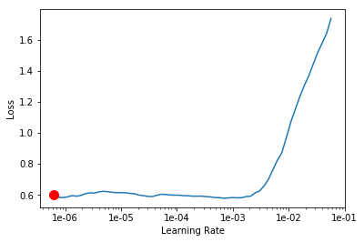

```python
learn.recorder.plot()
```

```python
learn.fit_one_cycle(8, max_lr=slice(3e-5,3e-4))
```

Total time: 02:14

| epoch | train_loss | valid_loss | error_rate |
| --- | --- | --- | --- |
| 1 | 0.607522 | 0.682315 | 0.199510 |
| 2 | 0.607361 | 0.683675 | 0.195838 |
| 3 | 0.629008 | 0.688352 | 0.195838 |
| 4 | 0.633477 | 0.681188 | 0.194614 |
| 5 | 0.618491 | 0.681408 | 0.195838 |
| 6 | 0.606884 | 0.684329 | 0.197062 |
| 7 | 0.625654 | 0.682711 | 0.192166 |
| 8 | 0.616363 | 0.683162 | 0.193390 |

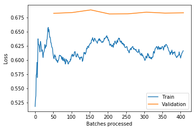

```python
learn.recorder.plot_losses()
```

```python
learn.save('stage-2')
```

## Interpretation

```python
learn.load('stage-2');
```

```python
interp = ClassificationInterpretation.from_learner(learn)
```

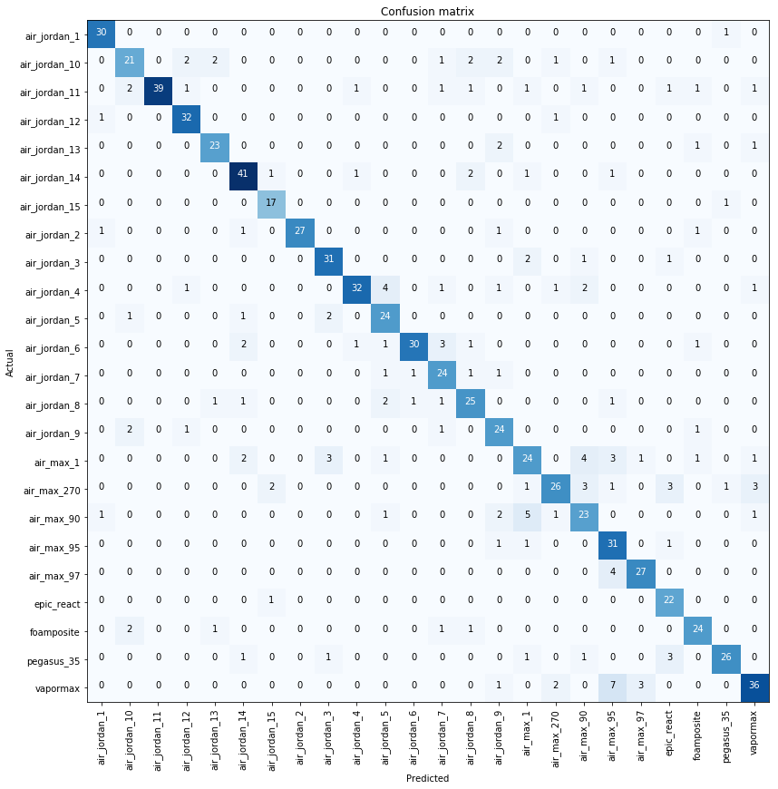

```python
# interp.plot_confusion_matrix() makes too small of a confusion matrix using defaults for this many classes
interp.plot_confusion_matrix(figsize=(12,12))
```

[figure not shown]

```python
interp.plot_top_losses(16, figsize=(15,11))
```

# Training Resnet50

```python
bs = 64
```

```python
np.random.seed(42)
data = ImageDataBunch.from_folder(path, train=".", valid_pct=0.2,
        ds_tfms=get_transforms(), size=299, bs=bs//2, num_workers=4).normalize(imagenet_stats)
```

```python
learn = create_cnn(data, models.resnet50, metrics=error_rate)
```

```
LR Finder is complete, type {learner_name}.recorder.plot() to see the graph.
Min numerical gradient: 4.37E-03
```

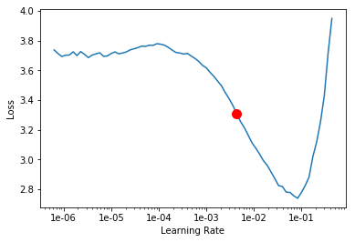

```python
learn.lr_find()
learn.recorder.plot()
```

```python
learn.fit_one_cycle(5)
```

Total time: 02:23

| epoch | train_loss | valid_loss | error_rate |
| --- | --- | --- | --- |
| 1 | 3.768328 | 3.387631 | 0.960832 |
| 2 | 3.821812 | 3.390353 | 0.964504 |
| 3 | 3.776157 | 3.383986 | 0.957160 |
| 4 | 3.804838 | 3.389931 | 0.958384 |
| 5 | 3.775692 | 3.384222 | 0.957160 |

```python
learn.save('stage-1-50')
```

```python
learn.unfreeze()
learn.fit_one_cycle(3, max_lr=slice(1e-6,1e-4))
```

Total time: 01:25

| epoch | train_loss | valid_loss | error_rate |
| --- | --- | --- | --- |
| 1 | 3.816280 | 3.381820 | 0.964504 |
| 2 | 3.793281 | 3.385331 | 0.963280 |
| 3 | 3.777779 | 3.392072 | 0.957160 |

```python
learn.save('stage-2-50')
```

```python
learn.fit_one_cycle(5)
```

Total time: 02:22

| epoch | train_loss | valid_loss | error_rate |
| --- | --- | --- | --- |
| 1 | 3.822473 | 3.384061 | 0.953488 |
| 2 | 3.797358 | 3.387615 | 0.962056 |
| 3 | 3.752917 | 3.386645 | 0.959608 |
| 4 | 3.783721 | 3.389186 | 0.963280 |
| 5 | 3.780045 | 3.392541 | 0.965728 |

```python
learn = create_cnn(data, models.resnet50, metrics=error_rate)
```

```python
learn.fit_one_cycle(5)
```

Total time: 02:22

| epoch | train_loss | valid_loss | error_rate |
| --- | --- | --- | --- |
| 1 | 1.723297 | 0.812714 | 0.228886 |
| 2 | 0.925321 | 0.552715 | 0.149327 |
| 3 | 0.541413 | 0.379012 | 0.102815 |
| 4 | 0.334193 | 0.324287 | 0.095471 |
| 5 | 0.244721 | 0.321443 | 0.093023 |

```python
learn.save('stage-3-50')
```

```
LR Finder is complete, type {learner_name}.recorder.plot() to see the graph.
Min numerical gradient: 1.32E-06
```

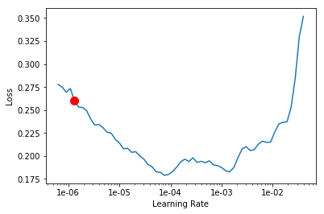

```python
learn.lr_find()
learn.recorder.plot()
```

```python
learn.unfreeze()
learn.fit_one_cycle(6, max_lr=slice(1e-6,1e-5))
```

Total time: 02:50

| epoch | train_loss | valid_loss | error_rate |
| --- | --- | --- | --- |
| 1 | 0.204805 | 0.315299 | 0.090575 |
| 2 | 0.208788 | 0.320464 | 0.093023 |
| 3 | 0.207821 | 0.322016 | 0.096695 |
| 4 | 0.202606 | 0.315001 | 0.090575 |
| 5 | 0.220137 | 0.321043 | 0.089351 |
| 6 | 0.207085 | 0.317602 | 0.089351 |

```python
learn.save('stage-4-50')
```

```python
learn.fit_one_cycle(6)
```

Total time: 02:50

| epoch | train_loss | valid_loss | error_rate |
| --- | --- | --- | --- |
| 1 | 0.217520 | 0.319160 | 0.093023 |
| 2 | 0.227447 | 0.323069 | 0.097919 |
| 3 | 0.214507 | 0.324367 | 0.094247 |
| 4 | 0.198693 | 0.318398 | 0.094247 |
| 5 | 0.209682 | 0.320650 | 0.090575 |
| 6 | 0.227057 | 0.318635 | 0.091799 |

```python
learn.save('stage-5-50')
```

```python
# It looks like stage-4-50 had the lowest error rate at 0.089
learn.load('stage-4-50')
```

[output not shown]

[output cut: 288 more lines]

[output not shown]

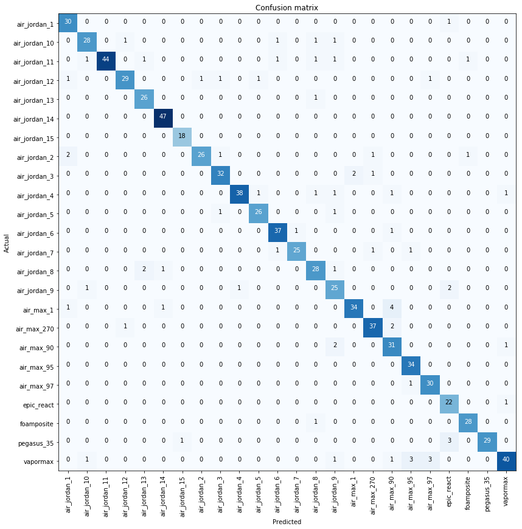

```python
# Resnet50 results
interp = ClassificationInterpretation.from_learner(learn)
interp.plot_confusion_matrix(figsize=(12,12))
```

[figure not shown]

```python
# Resnet50 results
interp.plot_top_losses(16, figsize=(15,11))
```

## Trying Out Resnet101

```python
learn2 = create_cnn(data, models.resnet101, metrics=error_rate)
```

```
Downloading: "https://download.pytorch.org/models/resnet101-5d3b4d8f.pth" to /home/jupyter/.torch/models/resnet101-5d3b4d8f.pth
178728960it [00:04, 37744623.62it/s]
```

```python
learn2.fit_one_cycle(5)
```

Total time: 03:40

| epoch | train_loss | valid_loss | error_rate |
| --- | --- | --- | --- |
| 1 | 1.727858 | 0.741123 | 0.214198 |
| 2 | 0.784969 | 0.424778 | 0.117503 |
| 3 | 0.438703 | 0.363216 | 0.080783 |
| 4 | 0.267901 | 0.280034 | 0.073439 |
| 5 | 0.184784 | 0.265869 | 0.061200 |

```python
learn2.save('stage-1-101')
```

```python
learn2.fit_one_cycle(5)
```

Total time: 03:40

| epoch | train_loss | valid_loss | error_rate |
| --- | --- | --- | --- |
| 1 | 0.164646 | 0.429504 | 0.082007 |
| 2 | 0.294140 | 0.404993 | 0.089351 |
| 3 | 0.221604 | 0.293126 | 0.070991 |
| 4 | 0.156987 | 0.216733 | 0.057528 |
| 5 | 0.109115 | 0.225996 | 0.064871 |

```python
learn2.save('stage-2-101')
```

```python
learn2.load('stage-2-101')
```

[output not shown]

[output cut: 560 more lines]

[output not shown]

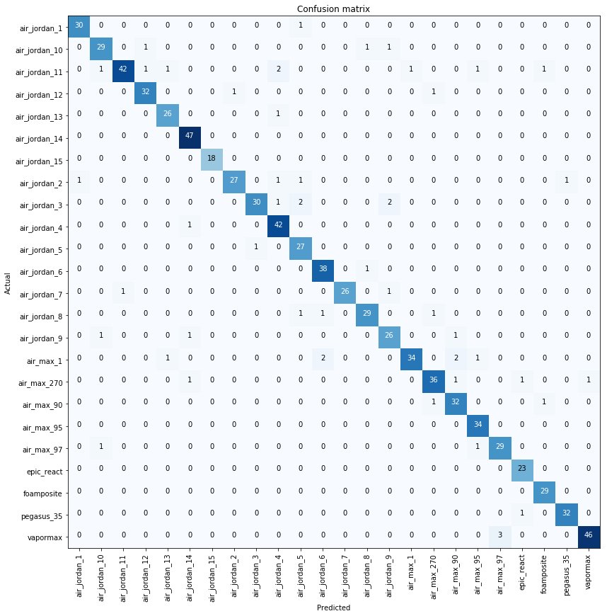

```python
# Resnet101 Results
interp2 = ClassificationInterpretation.from_learner(learn2)
interp2.plot_confusion_matrix(figsize=(12,12))
```

[figure not shown]

```python
# Resnet101 results
interp2.plot_top_losses(16, figsize=(15,11))
```

```python
learn2.export()
```

## Putting your model in production

We'll use the export for deploying on Render. The blog post I wrote covers the necessary steps.

```python
# Resnet50 model
learn.export()
```

This will create a file named 'export.pkl' in the directory where we were working that contains everything we need to deploy our model (the model, the weights but also some metadata like the classes or the transforms/normalization used).

## Testing model

You probably want to use CPU for inference, except at massive scale (and you almost certainly don't need to train in real-time). If you don't have a GPU that happens automatically. You can test your model on CPU like so:

```python
path
```

```
PosixPath('data/what_sneaker_2')
```

```python
defaults.device = torch.device('cpu')
```

[figure not shown]

```python
img = open_image(path/'air_jordan_3'/'00000004.jpg')
img
```

We create our `Learner` in production enviromnent like this, just make sure that `path` contains the file 'export.pkl' from before.

```python
learn = load_learner(path)
```

```python
pred_class,pred_idx,outputs = learn.predict(img)
pred_class
```

```
Category air_jordan_3
```

```python
outputs
```

```
tensor([2.8781e-10, 1.4255e-09, 8.6387e-11, 8.4601e-09, 8.9607e-08, 7.2350e-07,
        1.2619e-06, 1.3080e-06, 9.9999e-01, 6.4413e-09, 4.6450e-08, 6.9585e-09,
        7.8978e-08, 1.0802e-08, 1.5593e-08, 3.3806e-08, 1.0625e-07, 6.1343e-08,
        7.7403e-10, 1.4403e-07, 7.2610e-07, 3.4246e-10, 5.2651e-07, 4.3671e-07])
```

```python
pred = learn.predict(img)
```

The first two elements of the tuple are, respectively, the predicted class and label. Label here is essentially an internal representation of each class, since class name is a string and cannot be used in computation. To check what each label corresponds to, run:

```python
pred
```

```
(Category air_jordan_3,
 tensor(8),
 tensor([2.8781e-10, 1.4255e-09, 8.6387e-11, 8.4601e-09, 8.9607e-08, 7.2350e-07,
         1.2619e-06, 1.3080e-06, 9.9999e-01, 6.4413e-09, 4.6450e-08, 6.9585e-09,
         7.8978e-08, 1.0802e-08, 1.5593e-08, 3.3806e-08, 1.0625e-07, 6.1343e-08,
         7.7403e-10, 1.4403e-07, 7.2610e-07, 3.4246e-10, 5.2651e-07, 4.3671e-07]))
```

```python
pred[0]
```

```
Category air_jordan_3
```

```python
learn.data.classes
```

```
['air_jordan_1',
 'air_jordan_10',
 'air_jordan_11',
 'air_jordan_12',
 'air_jordan_13',
 'air_jordan_14',
 'air_jordan_15',
 'air_jordan_2',
 'air_jordan_3',
 'air_jordan_4',
 'air_jordan_5',
 'air_jordan_6',
 'air_jordan_7',
 'air_jordan_8',
 'air_jordan_9',
 'air_max_1',
 'air_max_270',
 'air_max_90',
 'air_max_95',
 'air_max_97',
 'epic_react',
 'foamposite',
 'pegasus_35',
 'vapormax']
```

```python
# probabilities and then classes
pred_result = pred[2].sort(descending=True)
pred_result
```

```
(tensor([9.9999e-01, 1.3080e-06, 1.2619e-06, 7.2610e-07, 7.2350e-07, 5.2651e-07,
         4.3671e-07, 1.4403e-07, 1.0625e-07, 8.9607e-08, 7.8978e-08, 6.1343e-08,
         4.6450e-08, 3.3806e-08, 1.5593e-08, 1.0802e-08, 8.4601e-09, 6.9585e-09,
         6.4413e-09, 1.4255e-09, 7.7403e-10, 3.4246e-10, 2.8781e-10, 8.6387e-11]),
 tensor([ 8,  7,  6, 20,  5, 22, 23, 19, 16,  4, 12, 17, 10, 15, 14, 13,  3, 11,
          9,  1, 18, 21,  0,  2]))
```

```python
top_3_pred_probs = pred_result[0][:3]
# convert probs to numpy array because I just want the numbers by themselves without 'tensor'
top_3_pred_probs = top_3_pred_probs.numpy()

top_3_pred_class_idxs = pred_result[1][:3]

# Convert label from 'air_jordan_3' to 'Air Jordan 3' after looking up proper index
top_3_pred_classes = [learn.data.classes[i].replace('_', ' ').title() for i in top_3_pred_class_idxs]

print(top_3_pred_probs)
print(top_3_pred_classes)

pred_top_3_output = list(zip(top_3_pred_classes, top_3_pred_probs))
print(pred_top_3_output)
```

```
[9.999944e-01 1.307971e-06 1.261867e-06]
['Air Jordan 3', 'Air Jordan 2', 'Air Jordan 15']
[('Air Jordan 3', 0.9999944), ('Air Jordan 2', 1.3079714e-06), ('Air Jordan 15', 1.2618672e-06)]
```

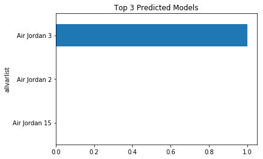

```python
plt.figure(figsize=(8,8))
df=pd.DataFrame({'allvarlist':top_3_pred_classes,'importances': top_3_pred_probs})
df.sort_values('importances',inplace=True)
df.plot(kind='barh',y='importances',x='allvarlist', legend=False, title='Top 3 Predicted Models');
```

```python
for i in pred_top_3_output:
    print(i)
```

```
('Air Jordan 3', 0.9999944)
('Air Jordan 2', 1.3079714e-06)
('Air Jordan 15', 1.2618672e-06)
```